# MSDS688 -- Artifical Intelligence

## Week 5 - Quantifying Uncertainty

[figure not shown]

```python
Image('images/kirchers-hydraulic-organ.png')
```

With the sixteenth-century advent of the pinned cylinder — a barrel with pins or bars sticking out, such as in a music box — even more complex lifelike machines were possible. Around this time, a new word also arose to describe human-like machines in particular: “android”, derived from Greek roots meaning “manlike”. This was the coinage of Gabriel Naudé, French physician and librarian, and personal doctor to none other than the automaton-loving Louis XIII.6

Pinned cylinders were the programming devices in automata and automatic organs from around 1600. In 1650, the German polymath Athanasius Kircher offered an early design of a hydraulic organ with automata, governed by a pinned cylinder and including a dancing skeleton.

Cite: Riskin, J. (n.d.). Frolicsome Engines: The Long Prehistory of Artificial Intelligence. Retrieved April 10, 2018, from https://publicdomainreview.org/2016/05/04/frolicsome-engines-the-long-prehistory-of-artificial-intelligence/

## Review - Algorithms used in solving CSPs

- **Depth First Search (DFS)**
  - Choose value from domain
  - Assure no contradictions
  - Assign value
- **DFS + Forward Checking (FC)**
  - After assignment eliminate incompatible values from neighbors domains
  - Re-instate values when backtracking
- **DFS + FC + Propagation through singleton domains**
  - Perform DFS + FC
  - If a *new* singleton results propagate through the singleton's neighbors
  - Repeat if any new singletons result, propagate through them too

## Review - Pre-processing algorithms for CSPs

- **AC-3**
  - Start on the node with the smallest domain
  - Remove any domain elements from adjacent domains for which there is no solution to the constraint
  - Repeat this process until all constraints are consistent in both directions

## Dealing with Uncertianty

- How long will it take me to get to the airport?
- 30 minutes, 1 hour, 2 hours, 8 hours???
- Problem: Partially observable (traffic, construction)
- Problem: Traffic data is noisy
- Problem: Too complex to model

## Logic

- 30 minutes *will* get me there on-time
- If no flat tires, no accidents, parking lot shuttle picks me up immediately, ...

## Probability

- The probablity I will get to the airport on time is 0.05 in 30 minutes
- The probablity I will get to the airport on time is 0.95 in 1 hour
- The probablity I will get to the airport on time is 0.9999 in 8 hours
- Summarizes effects of what we don't know and what can't evaluate

## Basic Probability Axioms

$$ \begin{align} & P(True) = 1 \quad P(False) = 0 \\ & 0 <= P(A) <= 1.0 \quad\text{where A is an event} \\ & P(A \cup B) = P(A) + P(B) - P(A \cap B) \quad\text{where A and b are events} \end{align} $$

## Mutually Exclusive Events

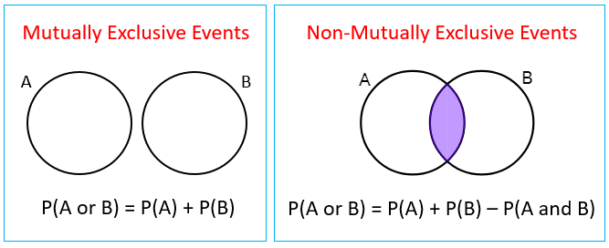

```python
Image('images/probability-a-or-b.png')
```

cite: https://www.onlinemathlearning.com/mutually-exclusive-events.html

## Mutually Exclusive vs Indpendent Events

- Mutually exclusive events do not overlap.
- $P(A \cap B) = 0$
- Indepentent events are unaffected by one another.
- $P(A \cap B) = P(A)\;\bullet\;P(B)$

[figure not shown]

cite: https://keydifferences.com/difference-between-mutually-exclusive-and-independent-events.html

## Conditional Probability

$$P(A \mid B) = \frac{P(A \cap B)}{P(B)}$$

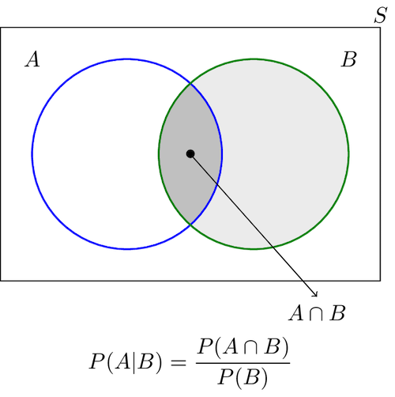

```python
Image('images/conditional_probability.png')
```

cite: https://www.probabilitycourse.com/chapter1/1_4_0_conditional_probability.php

## Chain Rule

$$P(A_1 \cup A_2 \cup A_3 \dots A_N) = P(A_1)P(A_2 \mid A_1)P(A_3 \mid A_2,A_1) \dots P(A_n \mid A_{n-1} A_{n-2} \dots A_{1})$$

## Example - Independence

- P(A)=1/3 --> probability it rains tomorrorow
- P(B)=1/2 --> probabilty of heads
- What is P(A|B)?
- P(A|B) = P(A) = 1/3 --> coin toss does not have anything to do with tomorrow's weather

cite: https://www.probabilitycourse.com/chapter1/1_4_4_conditional_independence.php

## Bayes Theorem

$$P(A\mid B) = \frac{P(B\mid A)P(A)}{P(B)}$$

## Joint Probability Table

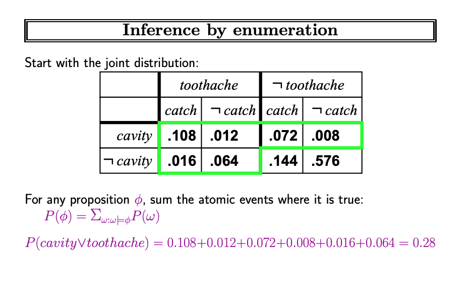

```python
Image('images/prob-inference-by-enumeration-1.png')
```

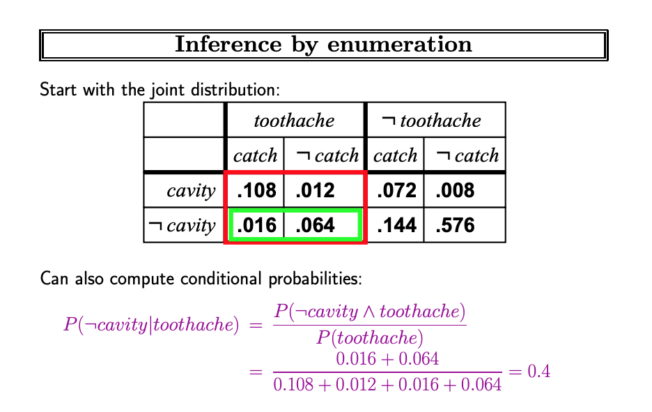

```python
Image('images/prob-inference-by-enumeration-2.png')
```

Cite: Chapter 13 - Uncertianty. (n.d.). Retrieved February 11, 2020, from http://aima.cs.berkeley.edu/instructors.html